# Stat 128 References 3 R Notebook

# Week 6 Machine Learning

## MACHINE LEARNING

### Supervised vs Unsupervised Training

- y <- f(x)
- y: Categorical: decision tree, find clusters
- y: Numerical: regression
- Decision = Binary split
- Deviance = how messed up your data is
- c(0,1) does not give good prediction
- Make 2 nodes each node homogeneous among 1 variable
- for K classes (categories) possible,
- each node or leaf splits into 2 groups with lowest possible deviance.

## Graph of deviance without N

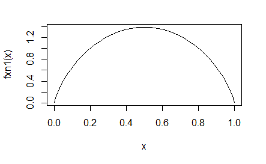

```r
fxn1 <- function(p){-2*(p*log(p)+(1-p)*log(1-p))}
curve(fxn1(x), from=0.001, to=0.999)
```

## Hitters example

```r
library(ISLR)
View(Hitters)
class(Hitters)
```

```
[1] "data.frame"
```

```r
dim(Hitters)
```

```
[1] 322  20
```

```r
head(Hitters)
```

|  | AtBat | Hits | HmRun | Runs | RBI | Walks | Years | CAtBat | CHits | CHmRun | CRuns | CRBI | CWalks | League | Division | PutOuts | Assists | Errors | Salary | NewLeague |
| --- | --- | --- | --- | --- | --- | --- | --- | --- | --- | --- | --- | --- | --- | --- | --- | --- | --- | --- | --- | --- |
| -Andy Allanson | 293 | 66 | 1 | 30 | 29 | 14 | 1 | 293 | 66 | 1 | 30 | 29 | 14 | A | E | 446 | 33 | 20 | NA | A |
| -Alan Ashby | 315 | 81 | 7 | 24 | 38 | 39 | 14 | 3449 | 835 | 69 | 321 | 414 | 375 | N | W | 632 | 43 | 10 | 475.0 | N |
| -Alvin Davis | 479 | 130 | 18 | 66 | 72 | 76 | 3 | 1624 | 457 | 63 | 224 | 266 | 263 | A | W | 880 | 82 | 14 | 480.0 | A |
| -Andre Dawson | 496 | 141 | 20 | 65 | 78 | 37 | 11 | 5628 | 1575 | 225 | 828 | 838 | 354 | N | E | 200 | 11 | 3 | 500.0 | N |
| -Andres Galarraga | 321 | 87 | 10 | 39 | 42 | 30 | 2 | 396 | 101 | 12 | 48 | 46 | 33 | N | E | 805 | 40 | 4 | 91.5 | N |
| -Alfredo Griffin | 594 | 169 | 4 | 74 | 51 | 35 | 11 | 4408 | 1133 | 19 | 501 | 336 | 194 | A | W | 282 | 421 | 25 | 750.0 | A |

```r
summary(Hitters)
```

```
     AtBat            Hits         HmRun
 Min.   : 16.0   Min.   :  1   Min.   : 0.00
 1st Qu.:255.2   1st Qu.: 64   1st Qu.: 4.00
 Median :379.5   Median : 96   Median : 8.00
 Mean   :380.9   Mean   :101   Mean   :10.77
 3rd Qu.:512.0   3rd Qu.:137   3rd Qu.:16.00
 Max.   :687.0   Max.   :238   Max.   :40.00

      Runs             RBI             Walks
 Min.   :  0.00   Min.   :  0.00   Min.   :  0.00
 1st Qu.: 30.25   1st Qu.: 28.00   1st Qu.: 22.00
 Median : 48.00   Median : 44.00   Median : 35.00
 Mean   : 50.91   Mean   : 48.03   Mean   : 38.74
 3rd Qu.: 69.00   3rd Qu.: 64.75   3rd Qu.: 53.00
 Max.   :130.00   Max.   :121.00   Max.   :105.00

     Years            CAtBat            CHits
 Min.   : 1.000   Min.   :   19.0   Min.   :   4.0
 1st Qu.: 4.000   1st Qu.:  816.8   1st Qu.: 209.0
 Median : 6.000   Median : 1928.0   Median : 508.0
 Mean   : 7.444   Mean   : 2648.7   Mean   : 717.6
 3rd Qu.:11.000   3rd Qu.: 3924.2   3rd Qu.:1059.2
 Max.   :24.000   Max.   :14053.0   Max.   :4256.0

     CHmRun           CRuns             CRBI
 Min.   :  0.00   Min.   :   1.0   Min.   :   0.00
 1st Qu.: 14.00   1st Qu.: 100.2   1st Qu.:  88.75
 Median : 37.50   Median : 247.0   Median : 220.50
 Mean   : 69.49   Mean   : 358.8   Mean   : 330.12
 3rd Qu.: 90.00   3rd Qu.: 526.2   3rd Qu.: 426.25
 Max.   :548.00   Max.   :2165.0   Max.   :1659.00

     CWalks        League  Division    PutOuts
 Min.   :   0.00   A:175   E:157    Min.   :   0.0
 1st Qu.:  67.25   N:147   W:165    1st Qu.: 109.2
 Median : 170.50                    Median : 212.0
 Mean   : 260.24                    Mean   : 288.9
 3rd Qu.: 339.25                    3rd Qu.: 325.0
 Max.   :1566.00                    Max.   :1378.0

    Assists          Errors          Salary
 Min.   :  0.0   Min.   : 0.00   Min.   :  67.5
 1st Qu.:  7.0   1st Qu.: 3.00   1st Qu.: 190.0
 Median : 39.5   Median : 6.00   Median : 425.0
 Mean   :106.9   Mean   : 8.04   Mean   : 535.9
 3rd Qu.:166.0   3rd Qu.:11.00   3rd Qu.: 750.0
 Max.   :492.0   Max.   :32.00   Max.   :2460.0
                                 NA's   :59
 NewLeague
 A:176
 N:146
```

```r
str(Hitters)
```

```
'data.frame':   322 obs. of  20 variables:
 $ AtBat    : int  293 315 479 496 321 594 185 298 323 401 ...
 $ Hits     : int  66 81 130 141 87 169 37 73 81 92 ...
 $ HmRun    : int  1 7 18 20 10 4 1 0 6 17 ...
 $ Runs     : int  30 24 66 65 39 74 23 24 26 49 ...
 $ RBI      : int  29 38 72 78 42 51 8 24 32 66 ...
 $ Walks    : int  14 39 76 37 30 35 21 7 8 65 ...
 $ Years    : int  1 14 3 11 2 11 2 3 2 13 ...
 $ CAtBat   : int  293 3449 1624 5628 396 4408 214 509 341 5206 ...
 $ CHits    : int  66 835 457 1575 101 1133 42 108 86 1332 ...
 $ CHmRun   : int  1 69 63 225 12 19 1 0 6 253 ...
 $ CRuns    : int  30 321 224 828 48 501 30 41 32 784 ...
 $ CRBI     : int  29 414 266 838 46 336 9 37 34 890 ...
 $ CWalks   : int  14 375 263 354 33 194 24 12 8 866 ...
 $ League   : Factor w/ 2 levels "A","N": 1 2 1 2 2 1 2 1 2 1 ...
 $ Division : Factor w/ 2 levels "E","W": 1 2 2 1 1 2 1 2 2 1 ...
 $ PutOuts  : int  446 632 880 200 805 282 76 121 143 0 ...
 $ Assists  : int  33 43 82 11 40 421 127 283 290 0 ...
 $ Errors   : int  20 10 14 3 4 25 7 9 19 0 ...
 $ Salary   : num  NA 475 480 500 91.5 750 70 100 75 1100 ...
 $ NewLeague: Factor w/ 2 levels "A","N": 1 2 1 2 2 1 1 1 2 1 ...
```

# Data and Prediction Challenge

## BINARY PARTITIONS

(handout) - Training set = data used to build the predictive model - Test dataset = used to access the performance of your model

### Data for Tree example

```r
library(MASS)
?Pima.tr # Diabetes in Pima Indian Women
dim(Pima.tr)
```

```
[1] 200   8
```

```r
head(Pima.tr)
```

|  | npreg | glu | bp | skin | bmi | ped | age | type |
| --- | --- | --- | --- | --- | --- | --- | --- | --- |
| 1 | 5 | 86 | 68 | 28 | 30.2 | 0.364 | 24 | No |
| 2 | 7 | 195 | 70 | 33 | 25.1 | 0.163 | 55 | Yes |
| 3 | 5 | 77 | 82 | 41 | 35.8 | 0.156 | 35 | No |
| 4 | 0 | 165 | 76 | 43 | 47.9 | 0.259 | 26 | No |
| 5 | 0 | 107 | 60 | 25 | 26.4 | 0.133 | 23 | No |
| 6 | 5 | 97 | 76 | 27 | 35.6 | 0.378 | 52 | Yes |

```r
summary(Pima.tr)
```

```
     npreg            glu              bp
 Min.   : 0.00   Min.   : 56.0   Min.   : 38.00
 1st Qu.: 1.00   1st Qu.:100.0   1st Qu.: 64.00
 Median : 2.00   Median :120.5   Median : 70.00
 Mean   : 3.57   Mean   :124.0   Mean   : 71.26
 3rd Qu.: 6.00   3rd Qu.:144.0   3rd Qu.: 78.00
 Max.   :14.00   Max.   :199.0   Max.   :110.00
      skin            bmi             ped
 Min.   : 7.00   Min.   :18.20   Min.   :0.0850
 1st Qu.:20.75   1st Qu.:27.57   1st Qu.:0.2535
 Median :29.00   Median :32.80   Median :0.3725
 Mean   :29.21   Mean   :32.31   Mean   :0.4608
 3rd Qu.:36.00   3rd Qu.:36.50   3rd Qu.:0.6160
 Max.   :99.00   Max.   :47.90   Max.   :2.2880
      age         type
 Min.   :21.00   No :132
 1st Qu.:23.00   Yes: 68
 Median :28.00
 Mean   :32.11
 3rd Qu.:39.25
 Max.   :63.00
```

```r
str(Pima.tr)
```

```
'data.frame':   200 obs. of  8 variables:
 $ npreg: int  5 7 5 0 0 5 3 1 3 2 ...
 $ glu  : int  86 195 77 165 107 97 83 193 142 128 ...
 $ bp   : int  68 70 82 76 60 76 58 50 80 78 ...
 $ skin : int  28 33 41 43 25 27 31 16 15 37 ...
 $ bmi  : num  30.2 25.1 35.8 47.9 26.4 35.6 34.3 25.9 32.4 43.3 ...
 $ ped  : num  0.364 0.163 0.156 0.259 0.133 ...
 $ age  : int  24 55 35 26 23 52 25 24 63 31 ...
 $ type : Factor w/ 2 levels "No","Yes": 1 2 1 1 1 2 1 1 1 2 ...
```

## First Tree: Construct a tree based on the training data Pima.tr to predict diabetes Type (a factor in data frame)

- Must start at the top and most important split

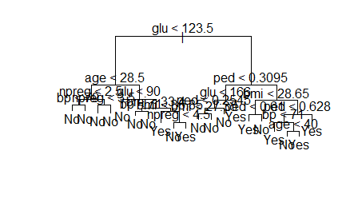

```r
library(tree)
pimatree <- tree(type~., data = Pima.tr) # type is already a factor
plot(pimatree)
text(pimatree)
```

```r
summary(pimatree)
```

```
Classification tree:
tree(formula = type ~ ., data = Pima.tr)
Variables actually used in tree construction:
[1] "glu"   "age"   "npreg" "bp"    "bmi"   "ped"
Number of terminal nodes:  20
Residual mean deviance:  0.4425 = 79.66 / 180
Misclassification error rate: 0.115 = 23 / 200
```

```r
pimatree
```

```
node), split, n, deviance, yval, (yprob)
      * denotes terminal node

  1) root 200 256.400 No ( 0.66000 0.34000 )
    2) glu < 123.5 109  87.330 No ( 0.86239 0.13761 )
      4) age < 28.5 74  31.120 No ( 0.94595 0.05405 )
        8) npreg < 2.5 58  10.100 No ( 0.98276 0.01724 )
         16) bp < 79 53   0.000 No ( 1.00000 0.00000 ) *
         17) bp > 79 5   5.004 No ( 0.80000 0.20000 ) *
        9) npreg > 2.5 16  15.440 No ( 0.81250 0.18750 )
         18) npreg < 3.5 6   8.318 No ( 0.50000 0.50000 ) *
         19) npreg > 3.5 10   0.000 No ( 1.00000 0.00000 ) *
      5) age > 28.5 35  43.570 No ( 0.68571 0.31429 )
       10) glu < 90 9   0.000 No ( 1.00000 0.00000 ) *
       11) glu > 90 26  35.430 No ( 0.57692 0.42308 )
         22) bmi < 33.4 10  10.010 No ( 0.80000 0.20000 )
           44) bp < 71 5   6.730 No ( 0.60000 0.40000 ) *
           45) bp > 71 5   0.000 No ( 1.00000 0.00000 ) *
         23) bmi > 33.4 16  21.930 Yes ( 0.43750 0.56250 )
           46) bmi < 35.85 6   0.000 Yes ( 0.00000 1.00000 ) *
           47) bmi > 35.85 10  12.220 No ( 0.70000 0.30000 )
             94) npreg < 4.5 5   0.000 No ( 1.00000 0.00000 ) *
             95) npreg > 4.5 5   6.730 Yes ( 0.40000 0.60000 ) *
    3) glu > 123.5 91 123.700 Yes ( 0.41758 0.58242 )
      6) ped < 0.3095 35  45.000 No ( 0.65714 0.34286 )
       12) glu < 166 27  28.600 No ( 0.77778 0.22222 )
         24) ped < 0.2545 19  23.700 No ( 0.68421 0.31579 )
           48) bmi < 27.35 6   0.000 No ( 1.00000 0.00000 ) *
           49) bmi > 27.35 13  17.940 No ( 0.53846 0.46154 ) *
         25) ped > 0.2545 8   0.000 No ( 1.00000 0.00000 ) *
       13) glu > 166 8   8.997 Yes ( 0.25000 0.75000 ) *
      7) ped > 0.3095 56  65.080 Yes ( 0.26786 0.73214 )
       14) bmi < 28.65 11  12.890 No ( 0.72727 0.27273 )
         28) ped < 0.61 5   6.730 Yes ( 0.40000 0.60000 ) *
         29) ped > 0.61 6   0.000 No ( 1.00000 0.00000 ) *
       15) bmi > 28.65 45  38.900 Yes ( 0.15556 0.84444 )
         30) ped < 0.628 28  31.490 Yes ( 0.25000 0.75000 )
           60) bp < 71 11   0.000 Yes ( 0.00000 1.00000 ) *
           61) bp > 71 17  23.030 Yes ( 0.41176 0.58824 )
            122) age < 40 10  13.460 No ( 0.60000 0.40000 ) *
            123) age > 40 7   5.742 Yes ( 0.14286 0.85714 ) *
         31) ped > 0.628 17   0.000 Yes ( 0.00000 1.00000 ) *
```

### Test how well the tree classifies the test data, Pima.te

```r
class(Pima.te)
```

```
[1] "data.frame"
```

```r
Pima.te[1,]
```

|  | npreg | glu | bp | skin | bmi | ped | age | type |
| --- | --- | --- | --- | --- | --- | --- | --- | --- |
| 1 | 6 | 148 | 72 | 35 | 33.6 | 0.627 | 50 | Yes |

```r
dim(Pima.te)
```

```
[1] 332   8
```

```r
head(Pima.te)
```

|  | npreg | glu | bp | skin | bmi | ped | age | type |
| --- | --- | --- | --- | --- | --- | --- | --- | --- |
| 1 | 6 | 148 | 72 | 35 | 33.6 | 0.627 | 50 | Yes |
| 2 | 1 | 85 | 66 | 29 | 26.6 | 0.351 | 31 | No |
| 3 | 1 | 89 | 66 | 23 | 28.1 | 0.167 | 21 | No |
| 4 | 3 | 78 | 50 | 32 | 31.0 | 0.248 | 26 | Yes |
| 5 | 2 | 197 | 70 | 45 | 30.5 | 0.158 | 53 | Yes |
| 6 | 5 | 166 | 72 | 19 | 25.8 | 0.587 | 51 | Yes |

```r
tail(Pima.te)
```

|  | npreg | glu | bp | skin | bmi | ped | age | type |
| --- | --- | --- | --- | --- | --- | --- | --- | --- |
| 327 | 1 | 128 | 88 | 39 | 36.5 | 1.057 | 37 | Yes |
| 328 | 2 | 88 | 58 | 26 | 28.4 | 0.766 | 22 | No |
| 329 | 9 | 170 | 74 | 31 | 44.0 | 0.403 | 43 | Yes |
| 330 | 10 | 101 | 76 | 48 | 32.9 | 0.171 | 63 | No |
| 331 | 5 | 121 | 72 | 23 | 26.2 | 0.245 | 30 | No |
| 332 | 1 | 93 | 70 | 31 | 30.4 | 0.315 | 23 | No |

```r
set.seed(223)
pima.pred <- predict(pimatree, newdata = Pima.te, type = 'class')
pima.pred
```

[output not shown]

### Compare actual type to prediction

```r
cbind(Pima.te, pima.pred)
rbind(pima.pred, Pima.te$type)
```

[output not shown]

### Confusion Table

```r
table(pima.pred, Pima.te$type)
```

```
pima.pred  No Yes
      No  173  44
      Yes  50  65
```

### Error Rate based on confusion table

```r
(44+50)/nrow(Pima.te)
```

```
[1] 0.2831325
```

## CROSS VALIDATION to determine optimal size of the tree - cv.tree

- cv.tree(object, rand, FUN = prune.tree, K = 10, …)

```r
set.seed(561)
pima.cv <- cv.tree(pimatree, , FUN=prune.misclass, K=10)
pima.cv
plot(pima.cv)
# Plot of $size vs $dev
```

[output not shown]

- dev = number of misclassification
- to reduce number of terminal nodes
- penalize overfitting or using too many variables
- Choose $size to correspond to the smallest value of $dev

## The improved, Pruned Tree

- Cross Validation is used to hep you find the size of the best pruned tree.

```r
pima.prune <- prune.misclass(pimatree,best = 5)
# best is the number of terminals you want
pima.prune
summary(pima.prune)
plot(pima.prune)
text(pima.prune, pretty = T) # must run immediately after plot
```

[output not shown]

### Predict test data using the pruned tree

```r
pima.prune.pred <- predict(pima.prune, newdata = Pima.te, type = 'class')
table(pima.prune.pred, truth = Pima.te$type)
pima.err2 <- (30+51)/nrow(Pima.te) #proportion misclassified with pruned tree on test data
pima.err2
```

[output not shown]

## Bootstrap Sample

- holding part of data out as test set and use other subsets as training sets = bootstrapping

```r
ds <- c(3,8,7,6,3,2,9,10)
set.seed(33)
dsample1 <- sample(x=ds, size = length(ds), replace = T)
dsample1
```

```
[1]  6  6  6 10  9  3  6  7
```

```r
dsample2 <- sample(ds, size = length(ds), replace = T)
dsample2
```

```
[1] 3 3 2 7 8 7 9 9
```

## Random Forest and Bagging (ISLR p.316-321)

Try to improve our predictions by growing a forest of unpruned trees. Each tree is constructed by drawing a bootstrap sample, and then building a tree using the bootstrap sample.

```r
library(randomForest)
set.seed(387)
pimaForest <- randomForest(type~., data = Pima.tr)
pimaForest
```

```
Call:
 randomForest(formula = type ~ ., data = Pima.tr)
               Type of random forest: classification
                     Number of trees: 500
No. of variables tried at each split: 2

        OOB estimate of  error rate: 27.5%
Confusion matrix:
     No Yes class.error
No  108  24   0.1818182
Yes  31  37   0.4558824
```

OOB = Out of Bag error = estimated misclassification rate

We will use error from the test data to find the best value of mtry argument for the randomForest function.

```r
error.by.mtry <- numeric(7)
oob.error <- numeric(7)
for (i in 1:7) {
  pimaForest2 <- randomForest(type~., data = Pima.tr, mtry = i, ntree = 400)
  oob.error[i] <- pimaForest2$err.rate[400]
  pred.mtry <- predict(pimaForest2, newdata = Pima.te, type = 'class')
  num.misclassified <- sum(Pima.te$type!=pred.mtry) # number misclassified in test set
  error.by.mtry[i] <- num.misclassified
  print(i)
}
```

```
[1] 1
[1] 2
[1] 3
[1] 4
[1] 5
[1] 6
[1] 7
```

```r
error.by.mtry
```

```
[1] 79 77 84 77 78 80 81
```

```r
error.by.mtry/332
```

```
[1] 0.2379518 0.2319277 0.2530120 0.2319277 0.2349398
[6] 0.2409639 0.2439759
```

```r
oob.error
```

```
[1] 0.270 0.280 0.280 0.280 0.295 0.270 0.300
```

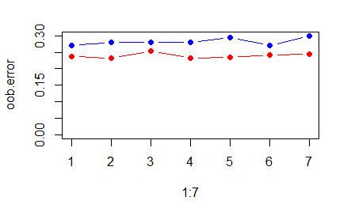

```r
plot(1:7, oob.error, col='blue', pch=19, type='b', ylim=c(0,.3))
points(1:7, error.by.mtry/332, col='red', pch=19, type='b')
```

```r
importance(pimaForest)
```

```
      MeanDecreaseGini
npreg         8.692578
glu          22.304791
bp            7.852450
skin          9.800046
bmi          12.420355
ped          13.587014
age          14.498880
```

The larger the Gini Index, the more mixed the observation in each terminal node across the classes. The Gini Index is small when all the observations in each terminal node tend to be from the same class.

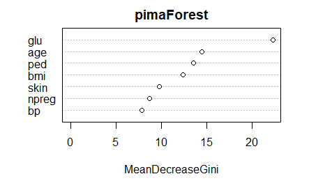

```r
varImpPlot(pimaForest)
```